# Information Needs for Identifying Bug-introducing Changes

### Paper Study 2 - Research Questions

Collect the frequency of each comment ended with the **?**. Data:

- the id of issue;
- the id of reviewers, devs, and reporters (all people involved in the process);
- the body of comments with the questions and aswers
- the size of comments
- the labels of issue/PR
- the code source related to the change. (later)
- the creation and update date of each comment, respecting the respective time zones.

##### **RQ01- With information needs can be captured from viewpoints?**[Done].

Study 1 collected from literature, social media, personal interview, and experience.

##### **RQ02 - How often each information need occur (frequency)?**

Metric: Compute the number of replies of each comment.

Example:

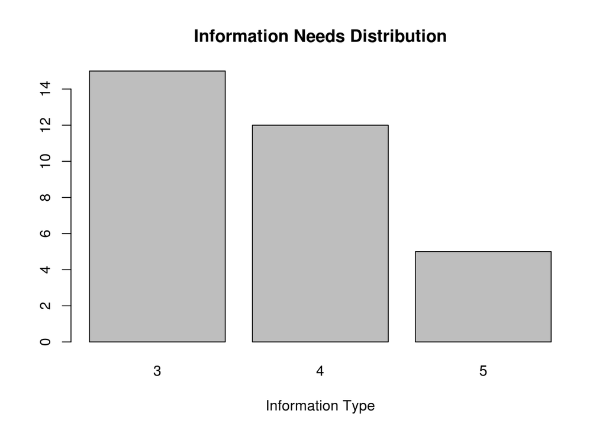

##### **RQ03 - Which information needs attract more discussion (density)?**

Metric: Compute the density of comments among the replies/time. The number of replies of each information needs view.

Example:

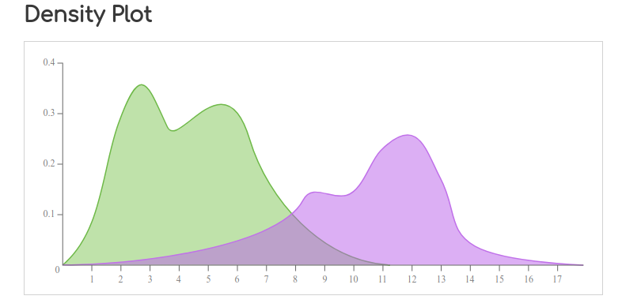

##### **RQ04 - How long does it take to get a response to each information (response time)?**

Metric: Compute the density of comments among the replies/time (in terms of minutes) needed to get a response in differents perspectives such as: category, addressee (dev or reviewer), topic (fix, enhancement, project). Example:

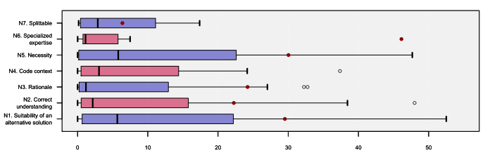

##### **RQ05 - Which information needs have been applied?**

Collect the information with at least one answer. How to automate this?.

##### **RQ06 - How long does it take to apply an information need?**

Collect the information with at least one answer and compute the time of interaction. How to automate this?.

##### **RQ07 - How do the information needs change over the development?**

Metric: Compute the number of times a certain information need appears in each iteration of a code review.

Example:

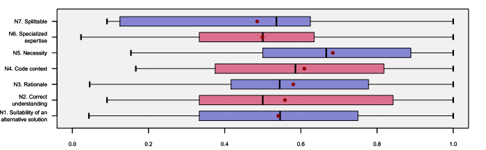

##### **RQ08 - How do the information needs impact in the software quality?**

If the presence of each information needs has a statistical difference on issues performing changes with bugs and without bugs.

Data: Collect the same amount of issues without bugs.

Metric: Compute a Spearman’s test.

##### **RQ09 - Is there a relationship between information needs and the number of issues/bugs/enchancements/fixes in a project?**

RQ09.1. Use a statistical modeling technique called Analysis of Variance (ANOVA) to measure which factors and interactions of factors influence the dependent variable. The independent variable is the *category*, while the dependent variable is the *issues*.

RQ9.2, ANOVA models (ARIMA) will be built with the *bugs* as the dependent variable.

RQ9.3, ANOVA models will be built with the *enchancements* as the dependent variable.

RQ9.4, ANOVA models will be built with the *fixes* as the dependent variable.

[What is the Connection Between Issues, Bugs, and Enhancements? (Lessons Learned from 800+ Software Projects)](https://dl.acm.org/citation.cfm?id=3183548)

##### **RQ10 - Are there temporal trends on information needs?**

Metric: Construct time series models with ARIMA to forecast future information needs.

##### **RQ11 - Are these correlations between informations needs?**

Metric: Compute the Spearman’s correlation tests between categories of information needs.

Example:

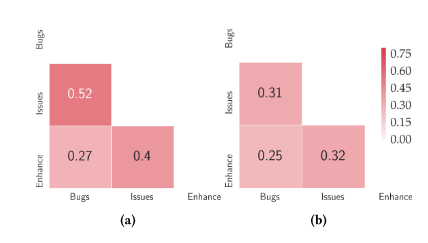

#### **RQ12 - Can information needs forecast for future bugs, enhancement, and fixes?**

Metric: Construct ARIMA models on time series data of categories for each project. Then, transfer ARIMA models between:

- information needs -> bugs
- information needs -> enhancements
- information needs -> fixes

Example:

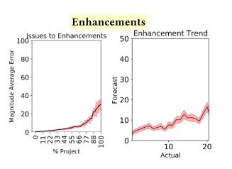